# Practical 4b - Geostatistical Modelling for Childhood malaria in the Gambia

Data were collected on 2035 children living in 65 different villages in the Gambia. Blood samples were taken for each child and measured for the presence of malarial parasites. Covariate data included the child’s age, whether or not they regularly slept under a bed net, and if so, whether this was treated (with permethrin insecticide). Two village-level covariates were also measured: an indicator of whether the village belonged to the Primary Health Care system, and a measure of the greenness of the village environment.

These data are freely available from the `geoR` package (Ribeiro Jr. and Diggle 2001) in `R` (R Core Team 2022). For this practical, the data are collected in a `.RData` file called `gambia_data.RData`.

The `gambia_data.RData` file includes a set of objects: + `M` = 2035 children + `N` = 65 villages

- `gambia` is a `data.frame` that includes the following 7 variables:

`x` = x-coordinate of the village (UTM)

`y` = y-coordinate of the village (UTM)

`pos`= presence (1) or absence (0) of malaria in a blood sample taken from the child

`age` = age of the child, in days

`bednet`is the bed net use and is in 3 categories: 1 = doesn’t sleep under bed net 2 = sleeps under untreated bed net 3 = sleeps under bed net impregnated with permethrin insecticide

`green` = satellite-derived measure of the greenness of vegetation in the immediate vicinity of the village

`phc` = binary indicator: 1/0 = village does/doesn’t belong to Primary Health Care system

- `gambia_data.RData` includes also an indicator variable (between 1 and 65) called `village` indicating which village the children belong to.

In this practical we want to evaluate the possible effect of **altitude** on the spatial variability of malaria in the country. As this predictor is not available in the current dataset, we will download it from the Shuttle Radar Topography Mission (SRTM) available through the package `geodata`. We aim also at performing predictions.

# 1. Install and load packages

IMPORTANT: This lab is implemented using `rmarkdown`. If it is not installed on your laptop, install it using `install.packages("rmarkdown")`

This lab requires also the following packages to be installed and attached: `INLA`,`dplyr`, `sf`, `spdep`, `tidyr`,`geodata`, `terra` ,`stars`, `RColorBrewer`, `ggplot2`, `tmap`, `cowplot`, `mapview`, `fmesher`.

- To check whether a package is installed you can use the query:

```r
is.element("sf", installed.packages())
```

- If FALSE is returned, then install the package function `install.packages()`, e.g.

```r
install.packages("sf", dep=TRUE)
```

- To install the entire suite of packages, we can use:

```r
#install.packages(c("dplyr","sf","spdep", "geodata","stars", "RColorBrewer", "ggplot2", "tmap", "cowplot", "mapview", "fmesher"), dependencies = TRUE, repos = "http://cran.r-project.org")
```

- Load the needed packages:

```r
library(INLA)         # Integrated Nested Laplace Approximation package
library(dplyr)        # A package for data manipulation
library(sf)           # Simple feature for R
library(spdep)        # Functions and tests for evaluating spatial patterns
                      # and autocorrelation
library(tidyr)        # Tools to help to create tidy data
library(geodata)      # Useful for spatial geographic data
library(terra)        # Package for creating, manipulating, visualizing spatial rasters
library(stars)        # Package for creating, manipulating, visualizing spatiotemporal arrays (raster and vector data cubes)

# Packages used for visualization
library(RColorBrewer) # A package providing colour palettes for shading maps
                      # and other plots
library(tmap)         # A package for static and interactive maps
library(ggplot2)      # A package that implements the grammar of graphics, which is a term used to
                      # break up graphs into semantic components, such as geometries and layers.
library(mapview)      # A package for interactive maps
library(cowplot)      # Add-on to ggplot. It provides features that help us with creating
                      # publication-quality figures
library(fmesher)      # A package for triangle meshes and other geometry tools
```

NOTE: if you have issues in working with `mapview` package in R Markdown, try to install it with `remotes::install_github("r-spatial/mapview")`.

# 2. The Gambia data: Manipulation and Explorative Analysis

- Load the data in `R`

```r
load(file="gambia_data.RData")
```

- Now, print the first few rows of the data:

```r
head(gambia)
```

- Create a data.frame object that includes all the data in the data.frame: `gambia` + the indicator variable `village` and produce the summary statistics of these data

```r
gambia = as.data.frame(cbind(gambia,village))
summary(gambia)
```

```
##        x                y                pos              age
##  Min.   :349631   Min.   :1458055   Min.   :0.0000   Min.   : 341
##  1st Qu.:381773   1st Qu.:1471011   1st Qu.:0.0000   1st Qu.: 708
##  Median :506400   Median :1482908   Median :0.0000   Median :1091
##  Mean   :490537   Mean   :1483355   Mean   :0.3572   Mean   :1080
##  3rd Qu.:594610   3rd Qu.:1496919   3rd Qu.:1.0000   3rd Qu.:1438
##  Max.   :622086   Max.   :1510610   Max.   :1.0000   Max.   :1856
##      green            phc             bednet         village
##  Min.   :28.85   Min.   :0.0000   Min.   :1.000   Min.   : 1.00
##  1st Qu.:40.85   1st Qu.:0.0000   1st Qu.:1.000   1st Qu.:15.00
##  Median :45.50   Median :1.0000   Median :2.000   Median :33.00
##  Mean   :46.90   Mean   :0.6835   Mean   :1.987   Mean   :32.52
##  3rd Qu.:52.25   3rd Qu.:1.0000   3rd Qu.:3.000   3rd Qu.:49.00
##  Max.   :58.95   Max.   :1.0000   Max.   :3.000   Max.   :65.00
```

- Compute the overall proportion (prevalence) of children with malaria. To do so, we can use the package `dplyr`

```r
prop = with(gambia, table(pos)) %>% prop.table()
prop
```

```
## pos
##         0         1
## 0.6427518 0.3572482
```

```r
prop*100
```

```
## pos
##        0        1
## 64.27518 35.72482
```

- The age is in days. Compute the age in years

```r
# age in years
gambia$agey = round(gambia$age/365, 2)
summary(gambia$agey)
```

- Calculate the prevalence of children infected in each village. To do so, we can use again the package `dplyr` and compute the proportion of positive tests: number of positive results divided by the total number of tests in each village, multiplied by 100

```r
prev = group_by(gambia, x, y) %>%
        summarize(total = n(),
        positive = sum(pos),
        prev = (positive/total)*100) %>%
  ungroup()

prev = as.data.frame(prev)

head(prev)
```

# 3. Obtain altitude for the entire country (source: Shuttle Radar Topography Mission (SRTM))

- Load in the altitude data for The Gambia, using the `elevation_30s` function from the `GeoData` package, with country identifier `GMB`

```r
# https://rdrr.io/cran/geodata/man/elevation.html

elev = elevation_30s(country = "GMB", mask = TRUE, path = tempdir())
```

- Now visualize this data with the standard `plot` function or using the `tm_raster` function in the `tmap` package

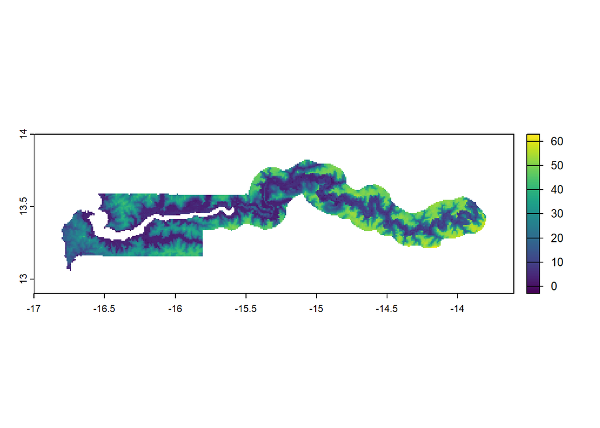

```r
plot(elev)
```

```r
st_crs(elev)

# or alternatively

tmap_mode("view")
tm_shape(elev) + tm_graticules() +
  tm_raster(style ="cont",title ="elevation",
  palette ="-Spectral", midpoint = NA) +
  tm_scale_bar(text.size =1) +
  tm_layout(inner.margins =0, main.title ="Gambia")
```

- To extract the altitude data at the coordinates of each village, we need *prev* and *elev* on the same projection. For the rest of this lab, we will work with the geographic coordinates latitude/longitude, `crs = "+proj=longlat +datum=WGS84"`.

To do this we first create an simple features, `sf`, object from the *prev* object, specifying the original UTM coordinate reference system, `"+proj=utm +zone=28"`, and use `st_transform` to reproject this data to “+proj=longlat +datum=WGS84”`

```r
sf.prev = st_as_sf(x = prev,
          coords = c("x", "y"),
          crs = "+proj=utm +zone=28", remove=FALSE)

prev = st_transform(sf.prev, crs="+proj=longlat +datum=WGS84")
```

- Finally, obtain the coordinates of the villages from the *prev* object, extract the point-referenced altitude at these locations using the `terra::extract` function, and remove the villages with no altitude measurements using the `drop_na` function from the `tidyr` package

```r
villages = st_coordinates(prev)
head(villages)

prev$alt = terra::extract(elev, villages)
head(prev)
prev$alt$GMB_elv_msk

# Remove villages with no measurements on altitude
prev = prev %>% drop_na()
```

# 4. Plotting the malaria prevalence

We have multiple ways of plotting point-referenced data. First, we can plot our data using a shapefile of our area of interest and creating the plot using `ggplot2` or `tmap`. Alternatively, we can use the `mapview` package to easily create interactive maps.

## Option 1: Plotting with `ggplot2` and `tmap`

Proceed with the following steps:

1. We start by reading the provided shapefile of Gambia using the function `st_read()` of the package `sf.` Call this object as *GMB*:

```r
GMB = st_read("gmb_adm_ndma_20220901_shp/gmb_admbnda_adm2_ndma_20220901.shp")
```

- Again, we can examine the sf object *GMB* and plot it using the `plot` function

```r
# Check geometry
st_geometry_type(GMB)

# Check what CRS this file data is in
st_crs(GMB)
# the data are encoded using a Unviersal Transverese Metacator (UTM) coordinate system.
# The units are in degrees, with axis as longitude and latitude

# Check the spatial extent of the shapefile (i.e. the geographic "edge" or location that is the furthest north, south east and west)
st_bbox(GMB)

# View all of the metadata and attributes for this shapefile object
GMB

# plot

plot(GMB)          # plot all the attributes
plot(GMB$geometry) # plot only the boundaries
```

2. Transform the coordinates of the shapefile *GMB*
- We use the `st_transform` function to specify the intended projection: `crs = "+proj=longlat +datum=WGS84"`.

```r
GMB = st_transform(GMB, crs="+proj=longlat +datum=WGS84")
```

3. We map the malaria prevalence with the location of the villages using `ggplot2` and `tmap`
- We use the `size` input in `ggplot` to put circles on the map, and color circles according to the value of the prevalence. For the color, we use `viridis` and `scale_color_binned` for a binned color scale.

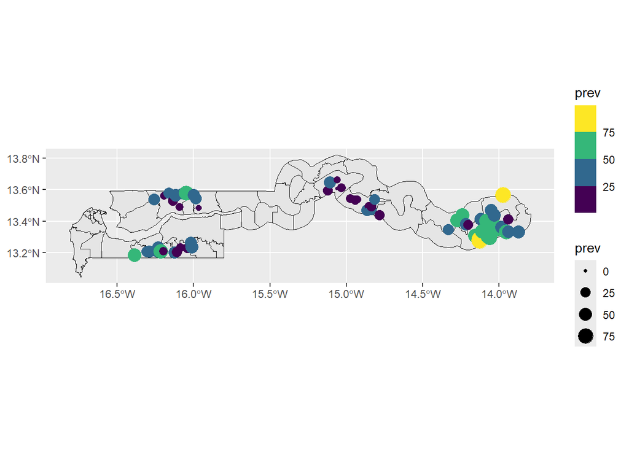

```r
ggplot() +
  geom_sf(data = GMB,  col = "black") +
  geom_sf(data = prev, aes(geometry = geometry, size = prev, col = prev))+
  scale_color_binned(type = "viridis")
```

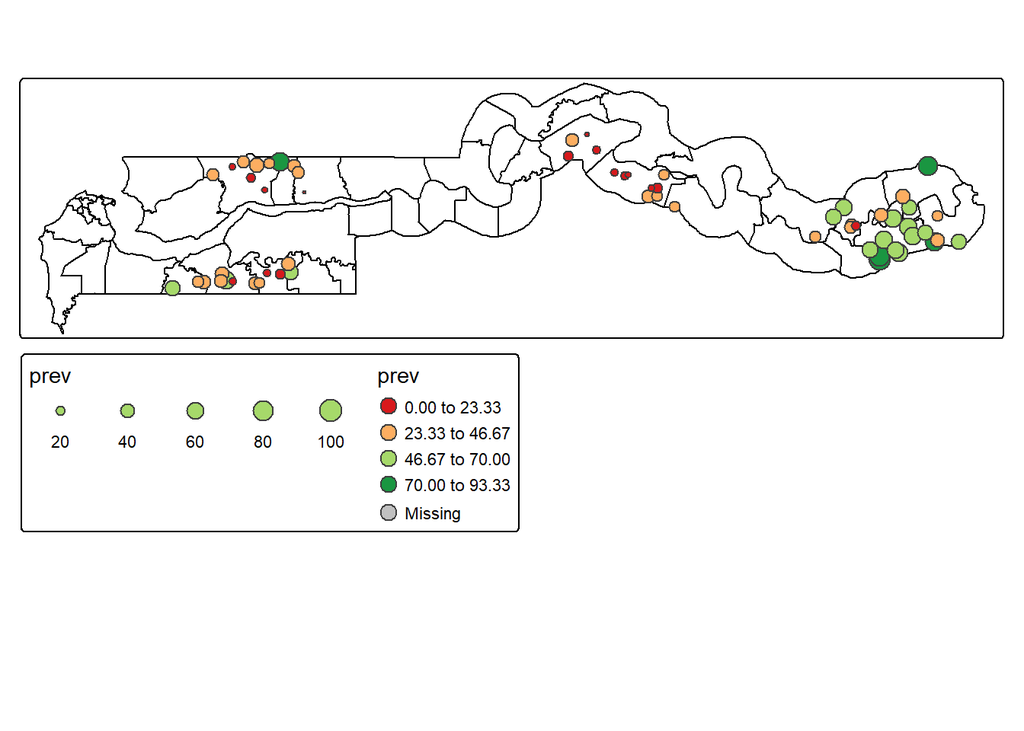

```r
tmap_mode("plot")
tm_shape(GMB) + tm_borders(lty="solid", col="black") +
  tm_shape(prev) + tm_bubbles("prev", col = "prev", palette="RdYlGn", style="equal", n=4) + tm_layout(legend.outside = TRUE)
```

## Option 2: Plotting with `mapview`

An alternative and potentially easier approach to plotting spatial data, is with the `mapview` packages.

This package allows you to plot spatial data on an interactive global map. The package uses the provided coordinates and coordinate reference system to map the data on the interactive global map.

- We simply call the `mapview` function with `zcol = "prev"`

```r
mapview(prev, zcol = "prev")
```

# 5. Geostatistical Modelling in `R-INLA` using the SPDE approach

We now fit a spatial model to the Gambia malaria prevalence and we estimate that at unsampled locations, quantifying the effect of altitude. The number of positive cases obtained at locations (i.e. villages), is conditional on the true prevalence of malaria and follows a Binomial distribution. Let $Y_i$ be the observed prevalence of malaria in village $i$, and $N_i$ be the total number of people tested in each village $i$, for $i=1, \dots, 65$. We assume the following model:

$$\begin{equation}
\begin{aligned}
Y_{i} & \sim \hbox{Binomial}(p_{i}, N_{i}); \;\;\; i=1,...,65\\
\hbox{logit} (p_{i}) & = \beta_{0} + \beta_1 X_{i} + \xi_i\\
\boldsymbol{\xi} &\sim GF(\boldsymbol{0}, \boldsymbol{\Sigma}) \\
\end{aligned}
\end{equation}$$

where $p_{i}$ is the true malaria prevalence to be estimated, then predicted, $\beta_{0}$ denotes the intercept and $\beta_1$ is the regression coefficient associated to altitude. The spatial random effect $\mathbf{\xi}$ is a stationary zero-mean Gaussian process with Matérn covariance function.

1. To implement this model, we need to construct a triangulated mesh to cover The Gambia. To build the mesh, we use the `inla.mesh.2d()` function from `INLA`, with:
- `loc`: matrix of point locations to be used as initial triangulation vertices,
- `max.edge`: the largest allowed triangle edge length,
- `cutoff`: the minimum allowed distance between points.

```r
coo = st_coordinates(prev)
mesh = inla.mesh.2d(loc = coo, max.edge = c(0.1,0.5), cutoff = 0.01)
```

- We can plot the mesh using the `plot` function.

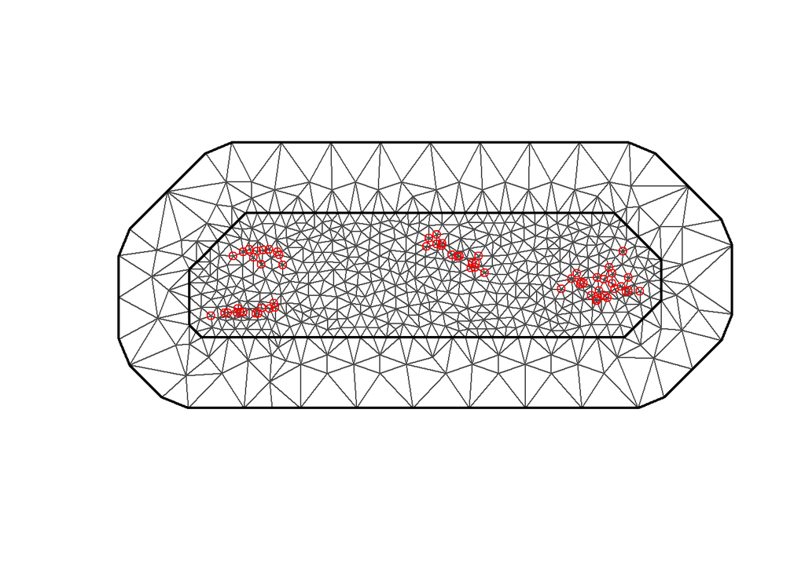

```r
plot(mesh)
points(coo, col = "red")
```

2. Build SPDE model
- We build the SPDE model on the mesh using the `inla.spde2.matern` function.

```r
spde = inla.spde2.matern(mesh = mesh, alpha = 2, constr = TRUE)
spde$n.spde
```

Where `alpha` is related to the smoothness parameter through $\alpha = \nu + d/2$ and setting `constr = TRUE` imposes an “integrate-to-zero” constraint.

3. Generate the index set
- To generate the index set we use the `inla.spde.make.index` function with spatial effect `spatial` and number of vertices equal to as in the SPDE model.

```r
s.index = inla.spde.make.index("spatial", spde$n.spde)
length(s.index$spatial) #665
```

4. Build the projection matrix
- To build the projection matrix A, we use the function `inla.spde.make.A`.

```r
A = inla.spde.make.A(mesh = mesh, loc = coo)
```

5. Specifying the prediction locations
- To create a set of prediction coordinates across The Gambia, we can aggregate our *elev* dataset into larger pixel sizes and get the coordinates using the `crds` function

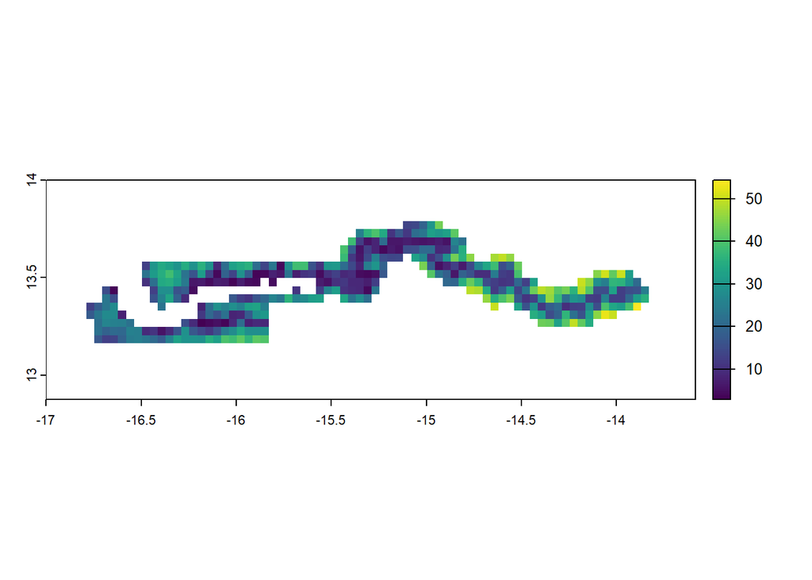

```r
ra = terra::aggregate(elev, fact = 5, fun = mean)
plot(ra)
```

```r
pred.points = crds(ra)
dim(pred.points)
```

```
## [1] 411   2
```

- Then, as in part 3, we extract the altitude at these prediction points, using `terra::extract` and create a matrix of the prediction points

```r
elev.points = terra::extract(elev, pred.points)
head(elev.points)
elev.points = cbind(pred.points, elev.points)

head(pred.points)
pred.coords = as.matrix(elev.points[,c("x", "y")])
```

6. Again using the `inla.spde.make.A` function to create the prediction projection matrix `A.pred`

```r
A.pred = inla.spde.make.A(mesh = mesh, loc = pred.coords)
```

7. Create INLA stacks

Using the `inla.stack` function, we create a stack for estimation from the *prev* data and the prediction stack from *elev.points*. Then, we put the stacks together using `inla.stack` again

```r
colnames(prev)
prev$altitude = prev$alt$GMB_elv_msk

# create the data stack

# estimation part
est.stack = inla.stack(data = list(y = prev$positive,
                                   numtrials = prev$total),
  A = list(A, 1),
  effects = list(s.index = 1:spde$n.spde, # the spatial effect
  data.frame(b0 = 1, altitude = prev$altitude)),
  tag = "est"
)

# prediction part
pred.stack = inla.stack(data = list(y = NA, numtrials = NA),
   A = list(A.pred, 1),
   effects = list(s.index = 1:spde$n.spde,
                  data.frame(b0 = 1, altitude =
                               elev.points$GMB_elv_msk)),
  tag = "pred"
)

# put all the stacks together (i.e. full.stack has est.stack and pred.stack)
full.stack = inla.stack(est.stack, pred.stack)
```

8. Specify the model formula

We specify the INLA model formula with an intercept term (remember that we need to remove the default intercept), `0 + b0`, adding altitude as a predictor, `altitude`, and the SPDE model term, `f(s.index, model = spde)`

```r
f = y ~ 0 + b0 + altitude + f(s.index, model = spde)
```

9. Run the INLA model and check the results

We run the INLA model using the `inla` function, formulating as the proposed model, where the model family in Binomial (`family = "binomial"`), with `numtrials` number of trials (`Ntrials = numtrials`), and `logit` link function (`control.family = list(link = "logit")`). We read in the stack data, predictors, and matrix A as usual.

```r
results = inla(f, family = "binomial", Ntrials = numtrials,
  control.family = list(link = "logit"),
  data = inla.stack.data(full.stack),
  control.predictor = list(
    compute = TRUE, link = 1,
    A = inla.stack.A(full.stack)
  )
)

summary(results)
```

# 6. Mapping the predicted malaria prevalence

1. Extract the indexes of the predicted points from the INLA stack, using the `inla.stack.index` function.

```r
pred.index = inla.stack.index(stack = full.stack, tag = "pred")$data
```

2. Extract the posterior predicted mean and 95% credible intervals from `results$summary.fitted values`.

```r
pred.mean = results$summary.fitted.values[pred.index, "mean"]

CI.low = results$summary.fitted.values[pred.index, "0.025quant"]
CI.high = results$summary.fitted.values[pred.index, "0.975quant"]
```

3. Join the posterior means and credible interval values to the prediction point coordinates and create an `sf` object

```r
pred.points = as.data.frame(pred.points)

pred.points = cbind(pred.points, pred.mean, CI.low, CI.high)

pred.sf = st_as_sf(pred.points, coords = c("x","y"), crs = "+proj=longlat +datum=WGS84")
```

4. Again we can map the malaria prevalence either using using `ggplot2` and `tmap` or the `mapview` package
- First we create a `SpatRaster` from the predicted data *pred.sf*

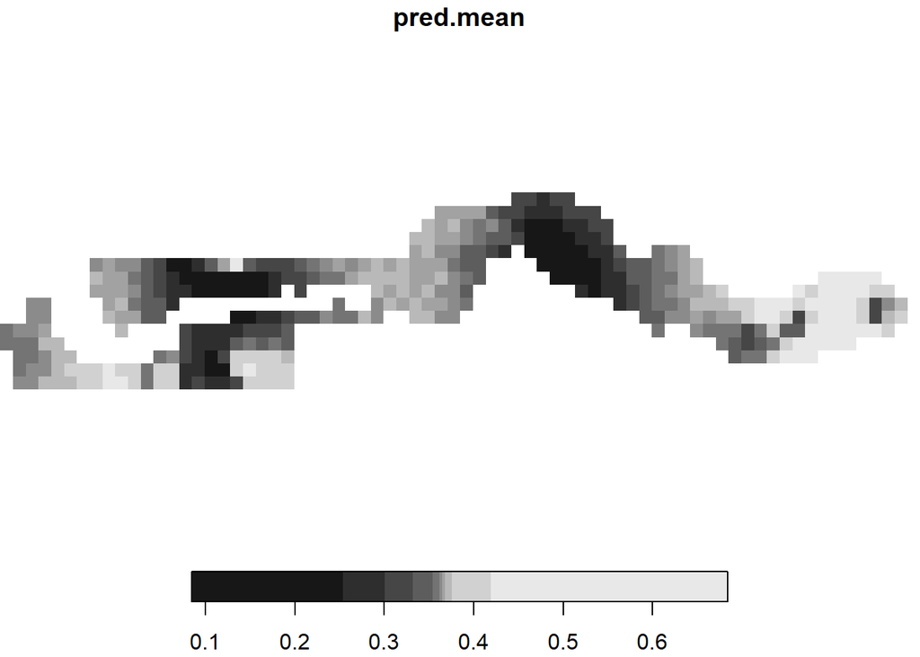

```r
pred.rast = st_rasterize(pred.sf %>% dplyr::select(pred.mean, CI.low, CI.high, geometry)) #function to rasterize an sf object

pred.rast$pred.mean[pred.rast$pred.mean == 0] = NA #replace zeros with NAs
plot(pred.rast)
```

- Then we plot, using `geom_stars` for `ggplot` and `tm_raster` for `tmap`

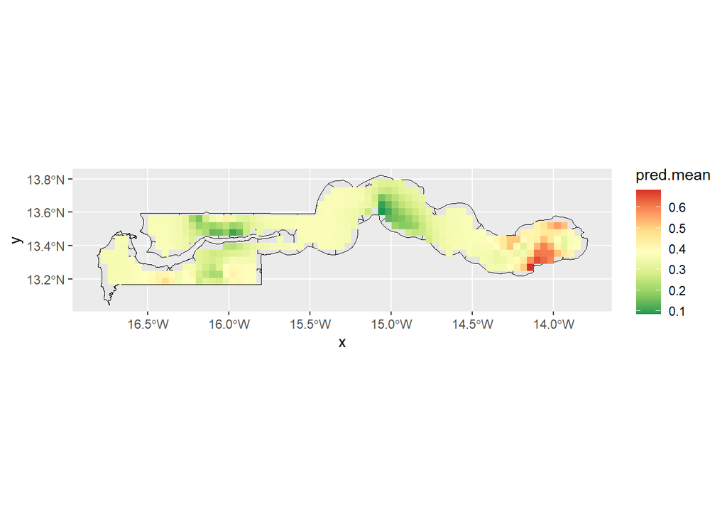

```r
# ggplot2
ggplot() +
  geom_sf(data = GMB,  col = "black") +
  geom_stars(data = pred.rast) +
  scale_fill_distiller(palette = "RdYlGn", na.value = NA)
```

```r
# tmap
tmap_mode("view")
tm_shape(GMB) + tm_borders(lty="solid", col="black") +
  tm_shape(pred.rast) + tm_raster(col = "pred.mean", palette="RdYlGn") + tm_layout(legend.outside = TRUE)
```

- Alternatively, in `mapview`:

```r
mapview(pred.rast, zcol = "pred.mean")
```

5. Similarly, we can also plot the upper and lower bounds of the 95% confidence interval in `mapview`
- We can use the `+` operator to add the CI data as additional layers:

```r
mapview(pred.rast, zcol = "pred.mean", layer.name = "Predicted Mean Prevelance") +
  mapview(pred.rast, zcol = "CI.low", layer.name = "CI Lower Bound") +
  mapview(pred.rast, zcol = "CI.high", layer.name = "CI Upper Bound")
```

See https://r-spatial.github.io/mapview/index.html for more information and examples using the `mapview` package.

# References

R Core Team. 2022. *R: A Language and Environment for Statistical Computing*. Vienna, Austria: R Foundation for Statistical Computing. https://www.R-project.org/.

Ribeiro Jr., P. J., and P. J. Diggle. 2001. “geoR: A Package for Geostatistical Analysis.” *R-NEWS* 1 (2): 15–18.